# What's The Story?

# COVID-19 in the USA: Things you didn't know.

### We were motivated to analyse COVID-19 data to understand

1. What has happened so far.
2. The impact on different parts of the country.
3. The factors driving regional differences.

### Why? It is highly topical, personally relevant, and a useful test of our skills.

#### Aaron Lewis, Tyler Ward, Ross Davidson.

##### Rice University Data Analytics Boot Camp.

##### Project 1 Presentation.

##### 25 June 2020.

# What Data?

### Data Sources

1. Cases and Deaths by County from USAFacts.org, aggregating data from CDC, state- and local- public health agencies.
2. Census Data from Census.gov.
3. Healthcare data from HRSA.gov.
4. Google API.
5. Data collected up to 15 June 2020.

### Data Cleanup

1. Cases and Deaths data required clean up prior to merging, esp. as county names were different.
2. HSRA data needed extensive wrangling to isolate a county-level score.
3. Census API took some work to understand.

### Sneak Peak

1. Charts of which areas have been most and least affected
2. Maps of where the virus has spread…. And where it hasn’t reached.
3. Statistical Analysis of demographic factors driving case rates.

# Question 1: How Did We Get Here?

```
Graph shows a dramatic rise in cases from mid March, then a slower rise in deaths.
```

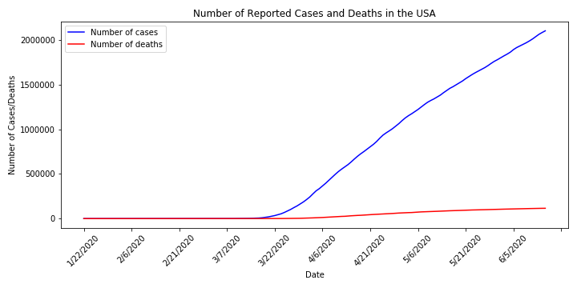

[output not shown]

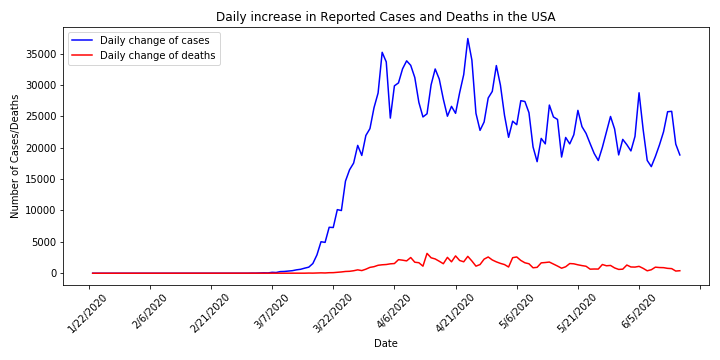

[output not shown]

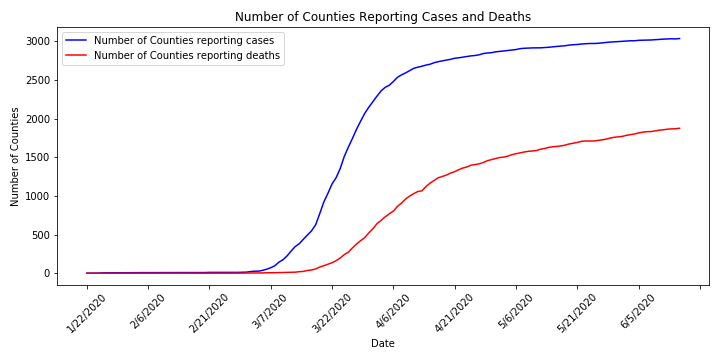

# Question 2: Are All States Created Equal?

```
It is not just population.
```

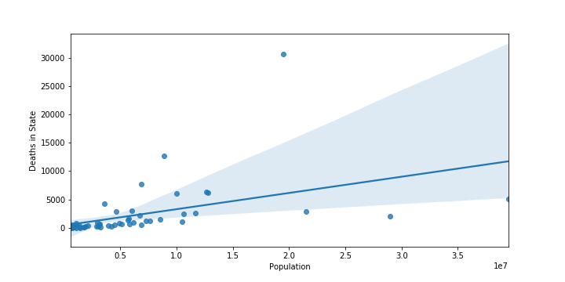

```
There is quite a variation in mortality (deaths/cases) across the States.
And it is not just New York.
```

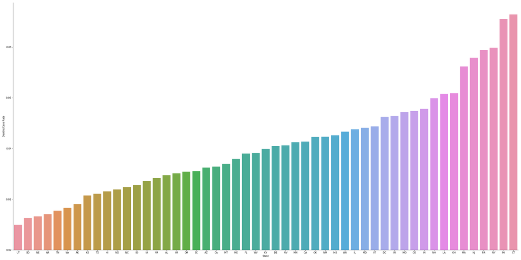

```
Box and Whisker Analysis suggests these outliers are significant.
```

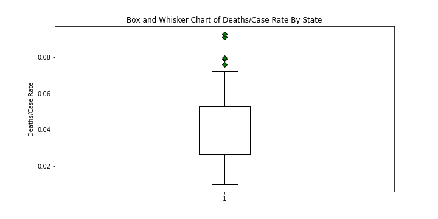

# Question 3: Where Is This Happening?

```
When mapped by county, it looks pretty widespread.
```

[figure not shown]

```
The North-Eastern States have the highest counts.
```

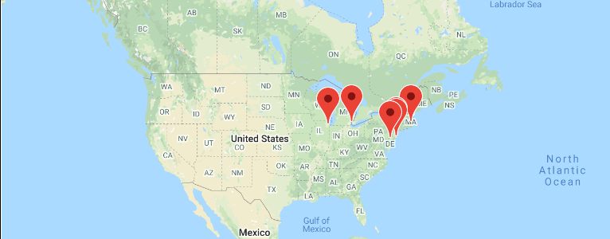

```
ANOVA analysis shows the Regional difference is significant.
```

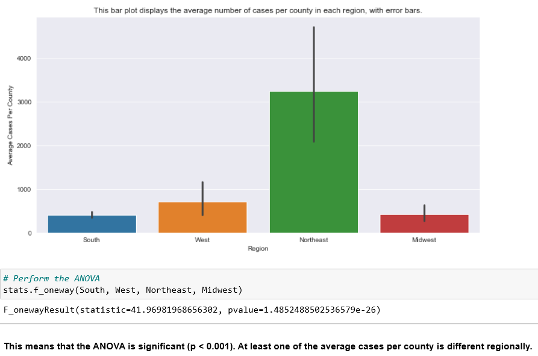

```
But Latitute is not a good explanation.
```

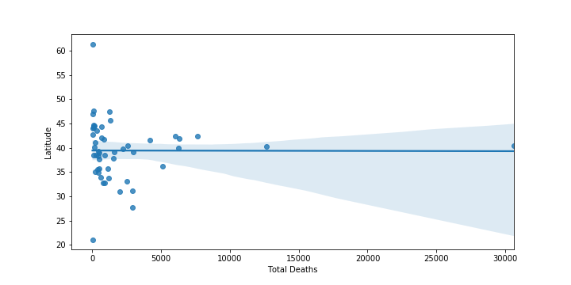

# So What Is Driving It?

# Question 4: Is It Access To Healthcare?

```
Counties with the worst HSPA score generally have higher Total Deaths per capita.
```

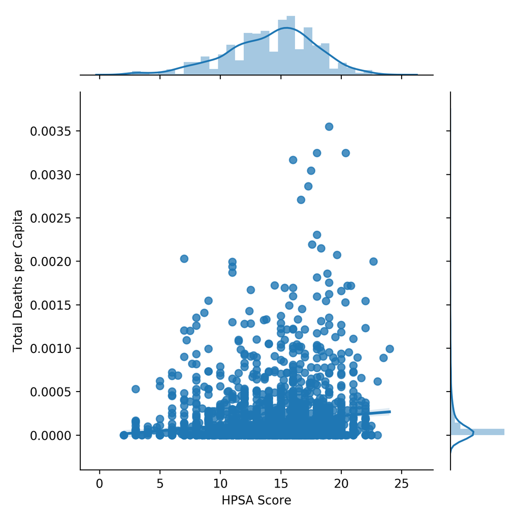

```
However, that relationship is weaker when we look at Mortality.
Counties with better health care do not seem to have better survival rates.
```

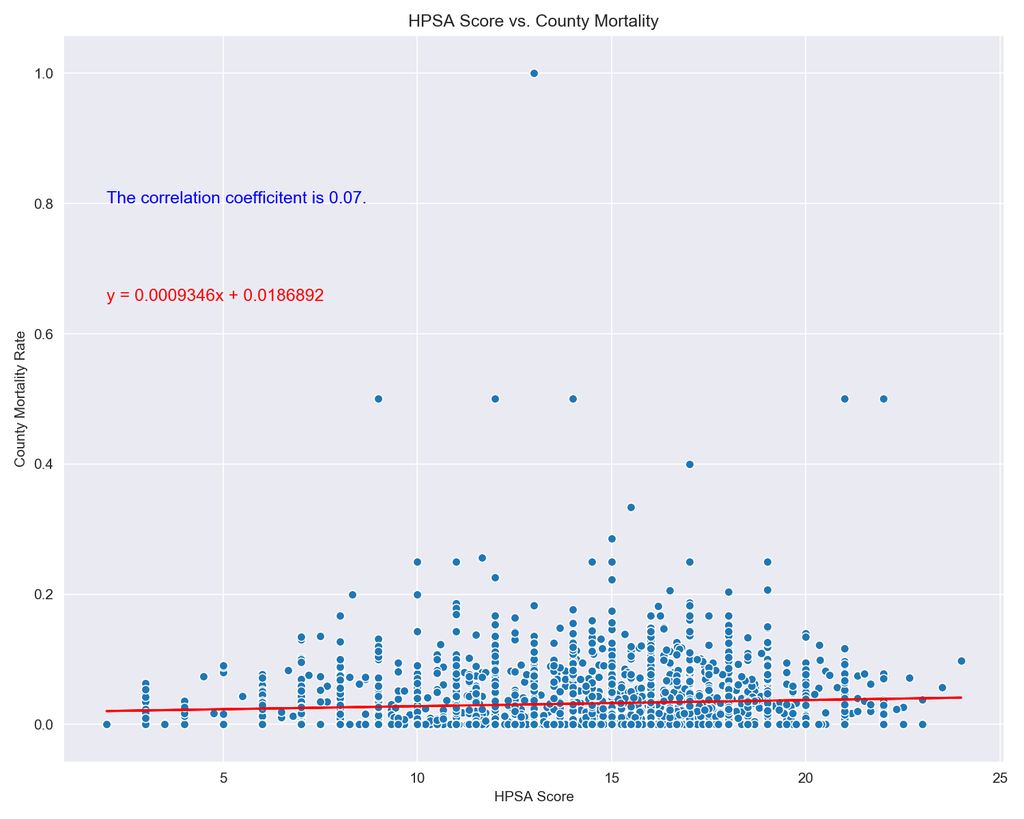

# Question 5: Is It Age and Health Insurance?

```
Cases v Over 65 with no Health Insurance shows some relationship.
Especially in the North East Region.
But the other regions do not have a strong relationship
```

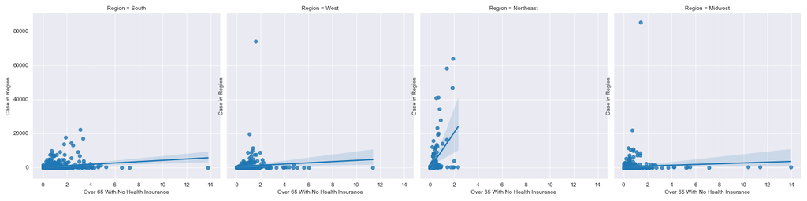

# Question 6: Is It Poverty?

```
Poverty levels show a much stronger relationship to cases across regions.
```

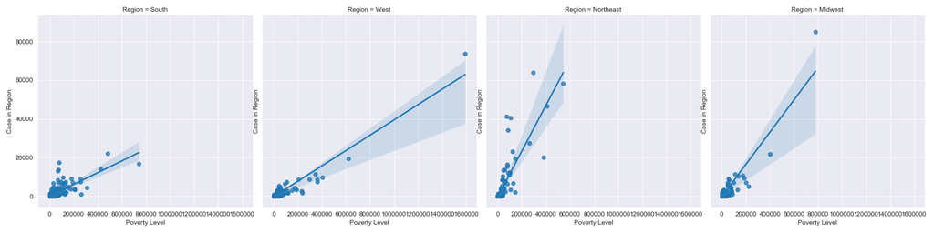

# Wrap Up

### We know more than we did before!

1. Primary finding: there is a statistically significantly difference across the USA.
2. Some of that difference can be explained by demographic factors.
3. Contrary to our expectation, access to health care or age do not seem to be signficant factors.
4. However, poverty levels appear to affect cases.
5. There are also clearly other factors at work, and the data is still evolving.
6. This has implications for how we understand and address what has happened.